# Lecture 37: Conjugate gradients

When $A$ is hermitian and positive definite, a famous method is available: conjugate gradients. There is a lot to say about CG overall, but to us it is a Krylov subspace method that minimizes a quantity other than the residual over $\mathcal{K}_n$. This quantity is $\|\epsilon_n\|_A$, where $\epsilon_n=A^{-1}b-x_n$ is the error and the norm is defined by $\|u\|_A^2=u^*Au$.

We won't use the iteration formulas here, just MATLAB's implementation of `pcg`.

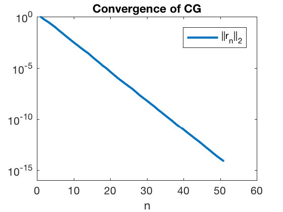

```matlab
m = 500;
kappa = 10;
lam = linspace(1,kappa,m)';
A = sparse(diag(lam));
b = randn(m,1);
b = b/norm(b);
[xCG,~,~,~,resnorm] = pcg(A,b,1e-14,100);
semilogy(resnorm,'.-')
hold on
ylim([1e-16 1])
xlabel('n')
title('Convergence of CG')
legend('||r_n||_2')
```

In this simple problem, we can calculate the true solution and therefore the error as well.

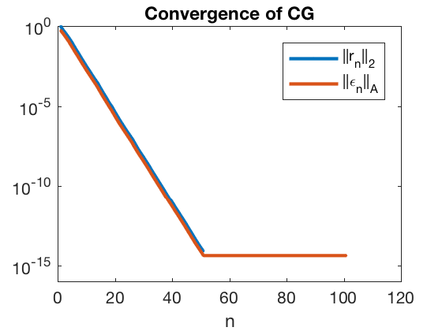

```matlab
x = b./diag(A);
Anorm = @(x) sqrt(x'*A*x);
Aerr = Anorm(x);
for n = 1:100
    [xCG,~] = pcg(A,b,1e-14,n);
    Aerr(n+1) = Anorm(x-xCG);
end
semilogy(resnorm,'.-')
hold on
semilogy(Aerr,'.-')
ylim([1e-16 1])
xlabel('n')
title('Convergence of CG')
legend('||r_n||_2','||\epsilon_n||_A')
```

## Effect of condition number

We already know that a large $\kappa(A)$ creates error in the solution of $Ax=b$. But it carries another penalty in Krylov methods: slower convergence. We have essentially the same result for CG as for MINRES, but using the $A$-norm of the errors:

$$ \frac{\|\epsilon_n\|}{\|\epsilon_0\|} \le 2 \left( \frac{\sqrt{\kappa}-1}{\sqrt{\kappa}+1} \right)^n,$$

where $\kappa=\kappa_2(A)$ equals the ratio of max to min eigenvalues.

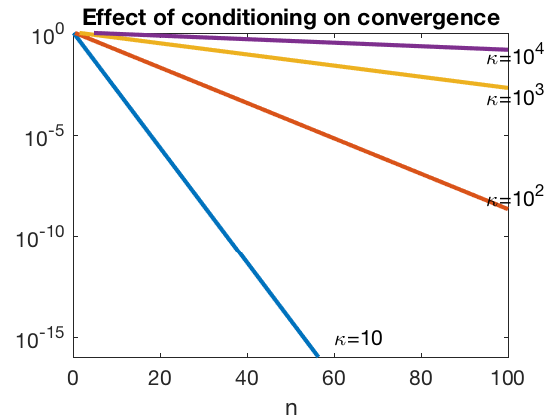

```matlab
for kappa = [10 100 1000 1e4]
    bound = 2*( (sqrt(kappa)-1)/(sqrt(kappa)+1) ).^(0:100);
    semilogy(0:100,bound*Aerr(1))
    hold on
end
ylim([1e-16 1])
text(60,1e-15,'\kappa=10')
text(95,1e-8,'\kappa=10^2')
text(95,1e-3,'\kappa=10^3')
text(95,1e-1,'\kappa=10^4')
title('Effect of conditioning on convergence')
xlabel('n')
```

The effect is the same for MINRES and CG, but measured in different terms. In particular, CG does *not* guarantee a nonincreasing residual norm.

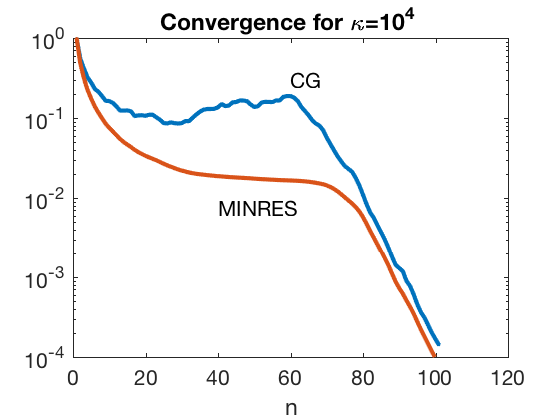

```matlab
kappa = 1e4;
lam = linspace(1,kappa,m)';
A = sparse(diag(lam));
b = randn(m,1);
b = b/norm(b);
[xCG,~,~,~,resnorm] = pcg(A,b,1e-14,100);
semilogy(resnorm,'.-')
hold on
text(60,0.3,'CG')
[xMR,~,~,~,resnorm] = gmres(A,b,[],1e-14,100);
semilogy(resnorm,'.-')
text(40,.0075,'MINRES')
ylim([1e-4 1])
xlabel('n')
title('Convergence for \kappa=10^4 ')
```

CG and MINRES are often not much different, practically speaking. MINRES also works for indefinite problems, while CG has considerably more (or at least better-known) theory behind it.